# BAYESIAN INFERENCE FOR NORMAL MEAN WITH UNKNOWN MEAN AND VARIANCE

12 Apr 2021 (*updated: 2021-04-14)*

## i. Admin & Startup

## Week 12 of 16 Focus

- Receive and act on HW 7 Ch. 11-13, HW 8 Ch.14 feedback, HW 9 Ch.15, Ch.16
- Assess progress via Midterm 3 canvas quiz, due Friday Apr 9 16.
- Practice on HW 10 Ch.17 content.
- Read Ch.17
- HW 10. Ch.17 due Friday Apr 16.

## Today’s plan

- Feedback from HWs. Focus on getting the exercises right.
- Prime by discussion via HW 10, Ch.17 exercise prompts.
- Discuss Ch. 17, part 1 roughly half of the 30 pages.
- Summarize, Revisit HW or Q & A

*Please contribute questions and comments*

## Feedback from HWs

- 11.2 joint sample vs. single observation. Make sure to use the correct variance!
- 12.4 Careful inputing the data. Keep the details straight and know how the function `normnp` works. t-interval review.
- 13.2 Careful inputing the data. Why am I seeing repeated people use incorrect input values? Such as sigma=6? Please help me understand. It is very strange. Use the posterior variance of \(\mu_d\) to calculate interval.
- Careful with variances versus standard deviation.
- Be certain you know how to enter the inputs to `Bolstad` functions. Explore output using `str()`.
- Extract values, don’t hardcode values later.
- 1-sided hypothesis testing use CDF. Why? 2-sided use CI. Why?
- One mistake ruins everything. Think hard about every answer.
- Use the R to check your work. Compute using formulas and compare to Bolstad functions and common R functions `t.test` or `lm`.
- Use my rmd source files from the slides. I demostrate almost everything. Review the slides while you work.

## I. Preview HW 10

Ch.17: CI - C3

## II. Discuss Ch. 17 with examples

## Discuss Ch. 17 with examples

- Overview of computing \(g(\mu, \sigma^2 | y)\).
- 17.1 The Joint Likelihood Function
- 17.2 Finding the Posterior when Independent Jeffrey’s Priors for \(\mu\) and \(\sigma^2\) are Used
  - Finding the Marginal Posterior for \(\mu\).
  - Another Way to Find the Marginal Posterior (Thm 17.1)
- 17.3 Finding the Posterior when a Joint Conjugate Prior for \(\mu\) and \(\sigma^2\) are Used
  - The Joint Conjugate Prior
  - Finding the Marginal Posterior for \(\mu\).
  - An Approximation to the Marginal Posterior for \(\mu\).
  - Example 17.1

## Ch. 17 Overview

- motivation
- setting
- big ideas

## 17.1 The Joint Likelihood Function

## 17.1 The Joint Likelihood Function

## 17.2 Finding the Posterior when Independent Jeffrey’s Priors for \(\mu\) and \(\sigma^2\) are Used

## Posterior Indep. Jeffrey’s priors

## Finding the Marginal Posterior for \(\mu\).

## Another Way to Find the Marginal Posterior

Thm 17.1

## 17.3 Finding the Posterior when a Joint Conjugate Prior for \(\mu\) and \(\sigma^2\) are Used

## Posterior when a Joint Conjugate Prior

## The Joint Conjugate Prior

## Marginal Posterior for \(\mu\).

## Approximation to the Marginal Posterior for \(\mu\).

## Example 17.1

## Using `bayes.t.test`

- Let’s look at the Appendix USING THE INCLUDED R FUNCTIONS on p.562.
- Read these sections while you use the functions.

## Additional Example 7.3

Let’s create synthetic paired data that are generated from normal distributions:

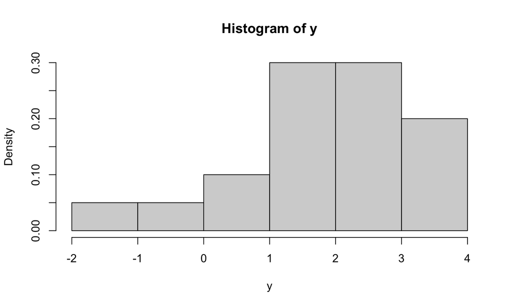

```r
n <- 20; mu1 <- 0; mu2 <- 2; sd1 <- 1; sd2 <- 1
y1 <- rnorm(n, mu1, sd1); y2 <- rnorm(n, mu2, sd2)
y <- y2-y1
hist(y, breaks="FD", freq=F)
```

## Additional Example 7.3

Use `bayes.t.test` to test \(H_0: \mu_{diff} \leq 0\) vs. \(H_0: \mu_{diff} > 0\) at the 5% significance level using independent Jeffrey’s priors for \(\mu\) and \(\sigma\).

First let’s read the documentation and ensure understanding.

```r
## ?bayes.t.test
```

## Additional Example 7.3

Now use `bayes.t.test` to test \(H_0: \mu_{diff} \leq 0\) vs. \(H_0: \mu_{diff} > 0\) at the 5% significance level using independent Jeffrey’s priors for \(\mu\) and \(\sigma\).

```r
(results <- bayes.t.test( x = y, alternative = "greater", mu = 0, paired = F, prior = c("jeffreys")))
```

```
##
##  One Sample t-test
##
## data:  y
## t = 6.3219, df = 19, p-value = 2.282e-06
## alternative hypothesis: true mean is greater than 0
## 95 percent confidence interval:
##  1.391235      Inf
## sample estimates:
## [1] 1.915017
```

```r
## t.test(x = y, alternative = "greater", mu = 0, paired = F) ## same
```

## Additional Example 7.3

Test the hypothesis again, this time using a joint conjugate prior, with prior mean \(m= 0\) and prior median value of \(\sigma=1\). Set your prior sample size to \(n_0 = 1\)

```r
m = 0; n0 = 1; sigMed = 1;
(results2 <- bayes.t.test( x = y, alternative = "greater", mu = 0, paired = F,
                          prior = "joint.conj", m = m, n0 = n0, sig.med = sigMed))
```

```
##
##  One Sample t-test
##
## data:  y
## t = 6.1475, df = 21, p-value = 2.119e-06
## alternative hypothesis: true mean is greater than 0
## 95 percent confidence interval:
##  1.313321      Inf
## sample estimates:
## [1] 1.823825
```

## Additional Example 7.3

Now test the the 2-sided hypothesis \(H_0: \mu_{diff} \neq 0\) vs. \(H_0: \mu_{diff} = 0\), with Jeffrey’s priors.

```r
(results3 <- bayes.t.test( x = y, alternative = "two.sided", mu = 0, paired = F,
                          prior = "jeffreys"))
```

```
##
##  One Sample t-test
##
## data:  y
## t = 6.3219, df = 19, p-value = 4.564e-06
## alternative hypothesis: true mean is not equal to 0
## 95 percent confidence interval:
##  1.281007 2.549026
## sample estimates:
## [1] 1.915017
```

```r
## or
a <- 0.05
tstar <- qt( p = 1-a/2, df = results3$parameter)
c( results3$result$mean - tstar*sqrt( results3$result$var ), results3$result$mean + tstar*sqrt( results3$result$var ) )
```

```
## [1] 1.281007 2.549026
```

## Closing (5 min)

- Summary
- HW discussion
- other?